# Final Proj - Progress

Masato Takahashi

# Data

## National Health Survey (PNS)

### About (copy-pasted)

The PNS is a probabilistic sampling nationwide household survey conducted by IBGE. It aims to ‘evaluate health conditions, health service access’ as well as perform ’surveillance of noncommunicable diseases and their social determinants. The PNS targets individuals aged 15 and over. In the PNS of 2019, a total of 279,382 households and 94,114 respondents to the individual questionnaire were included. Individual respondents were randomly selected from all household members aged 15 and above. The survey collected individual socio-demographic and contained modules addressing general health status, lifestyle, communicable and NCDs and health service usage, among others. Weighting of responses are adjusted for likelihood of selection and rate of non-response by sex and age category.

### Data handling

```r
pns_2019 <- readRDS("DL/PNS_2019.rds")

# Work in progress
```

## Mortality Information System (SIM)

**To be confirmed / discussed**  
- What is the unit?  
- What does "-" mean in the original CSV file? Would it be a problem to replace them with zeros?  
- Why does it not have variables "ch_19" and "ch_21"?

### About (copy-pasted)

Data consolidated by municipality and cause of **death** by ICD-10 chapter (ICD-10 is the 10th revision of the International Statistical Classification of Diseases and Related Health Problems, a medical classification list by the World Health Organization). Note that you are going to be working with ICD-10 chapters, and not with specific diseases. For example, you are not going to find Covid-19, but Diseases of the Respiratory System (chapter 10).

### Information on variables (same applies to the SIH data below)

| **Variable** | **Name** | **Description** | **SIM data** **2010** | **SIM data** **2020** | **SIH data** **2010** | **SIH data** **2020** |
| --- | --- | --- | --- | --- | --- | --- |
| ch_01 | Chapter 1 | Certain Infectious and Parasitic Diseases | ✔ | ✔ | ✔ | ✔ |
| ch_02 | Chapter 2 | Neoplasms | ✔ | ✔ | ✔ | ✔ |
| ch_03 | Chapter 3 | Disease of the blood and blood-forming organs and certain disorders involving the immune mechanism | ✔ | ✔ | ✔ | ✔ |
| ch_04 | Chapter 4 | Endocrine, Nutritional, and Metabolic Diseases | ✔ | ✔ | ✔ | ✔ |
| ch_05 | Chapter 5 | Mental, Behavioral and Neurodevelopmental disorders | ✔ | ✔ | ✔ | ✔ |
| ch_06 | Chapter 6 | Diseases of the Nervous System | ✔ | ✔ | ✔ | ✔ |
| ch_07 | Chapter 7 | Diseases of the Eye and Adnexa | ✔ | ✔ | ✔ | ✔ |
| ch_08 | Chapter 8 | Diseases of the Ear and Mastoid Process | ✔ | ✔ | ✔ | ✔ |
| ch_09 | Chapter 9 | Diseases of the Circulatory System | ✔ | ✔ | ✔ | ✔ |
| ch_10 | Chapter 10 | Diseases of the Respiratory System | ✔ | ✔ | ✔ | ✔ |
| ch_11 | Chapter 11 | Diseases of the Digestive System | ✔ | ✔ | ✔ | ✔ |
| ch_12 | Chapter 12 | Diseases of the Skin and Subcutaneous Tissue | ✔ | ✔ | ✔ | ✔ |
| ch_13 | Chapter 13 | Diseases of the Musculoskeletal System and Connective Tissue | ✔ | ✔ | ✔ | ✔ |
| ch_14 | Chapter 14 | Diseases of Genitourinary System | ✔ | ✔ | ✔ | ✔ |
| ch_15 | Chapter 15 | Pregnancy, Childbirth, and the Puerperium | ✔ | ✔ | ✔ | ✔ |
| ch_16 | Chapter 16 | Certain Conditions Originating in the Perinatal Period | ✔ | ✔ | ✔ | ✔ |
| ch_17 | Chapter 17 | Congenital malformations, deformations, and chromosomal abnormalities | ✔ | ✔ | ✔ | ✔ |
| ch_18 | Chapter 18 | Symptoms, signs, and abnormal clinical and laboratory findings, not elsewhere classified | ✔ | ✔ | ✔ | ✔ |
| ch_19 | Chapter 19 | Injury, poisoning, and certain other consequences of external causes |  |  | ✔ | ✔ |
| ch_20 | Chapter 20 | External Causes of Morbidity | ✔ | ✔ | ✔ | ✔ |
| ch_21 | Chapter 21 | Factors influencing health status and contact with health services |  |  | ✔ |  |

### Data handling

```r
# Import the datasets

for (i in c(2010, 2020)) {

  name <- paste0("sim_", i)
  tmp <- read.csv(paste0("DL/SIM_", i, ".csv"), header = TRUE) %>%
    as_tibble() %>%
    mutate_if(is.character, as.numeric) %>%
    mutate(year = i)
  assign(name, tmp)

}

rm(list = c("i", "name", "tmp"))

# --------------------------------------------------------------------

# Combine the tibbles

sim <- sim_2010 %>%
  bind_rows(sim_2020) %>%
  select(municipality, year, everything()) %>%
  arrange(year, municipality)

# --------------------------------------------------------------------

# Remove temporary files

rm(list = c("sim_2010", "sim_2020"))
```

## Hospitalizations Information System (SIH)

**To be confirmed / discussed**  
- What is the unit?  
- What does "-" mean in the original CSV file? Would it be a problem to replace them with zeros?

### About (copy-pasted)

Data consolidated by municipality and disease that caused the **hospitalization** (by ICD-10 chapter). This data covers all hospital admissions covered by SUS, both in public facilities and in accredited private hospitals and are recorded by the patient’ municipality of origin, and not the municipality where she was hospitalized.

### Data handling

```r
# Import the datasets
# --- Change the first line to "c(2010, 2020)" once we have the 2020 data

for (i in c(2010, 2020)) {

  name <- paste0("sih_", i)
  tmp <- read.csv(paste0("DL/SIH_", i, ".csv"), header = TRUE) %>%
    as_tibble() %>%
    mutate_if(is.character, as.numeric) %>%
    mutate(year = i)
  assign(name, tmp)

}

rm(list = c("i", "name", "tmp"))

# --------------------------------------------------------------------

# Combine the tibbles

sih <- sih_2010 %>%
  bind_rows(sih_2020) %>%
  select(municipality, year, everything()) %>%
  arrange(year, municipality)

# --------------------------------------------------------------------

# Remove temporary files

rm(list = c("sih_2010", "sih_2020"))
```

## Health Infrastructure Database (CNES)

**To be confirmed / discussed**  
- For now, I assume that the same names are given to the same variables, but it is good have a confirmation (e.g., UNIDADE MOVEL TERRESTRE appears only in the 2010 data but we should make sure that variable does not appear in the 2020 data under a different name).  
- How do we define human and physical infrastructure? For instance, should we include social assistants when calculating "human infrastructure" in this context?

- The number of variables are...  
* Health professionals: 9 in 2010 and 10 in 2020  
* Facilities: 27 in 2010 and 39 in 2020  
* Equipment: 5 in both 2010 and 2020

### About (copy-pasted)

Administrative dataset that contains information on every health facility in Brazil. The data include the location, type of services provided, type of establishment, and the human resources available in each facility. Auxiliary microdata also includes an individual identification number for each professional, which allows to identify the number of different professionals enrolled in each facility as well as their average number of hours worked per week.

### Data handling

```r
# Import the datasets
# --- cnes_1: professionals, cnes_2: facilities, cnes_3: equipments

tmp_list <- c("professionals", "facilities", "equipments")

for (i in 1:3) {

  for (j in c(2010, 2020)) {

    name <- paste0("cnes_", i, "_", j)
    tmp <- read.csv(
      paste0("DL/health_", tmp_list[[i]], "_", j, ".csv"),
      header = TRUE
      ) %>%
      as_tibble() %>%
      mutate_if(is.character, as.numeric)
    assign(name, tmp)

  }

}

rm(list = c("tmp_list", "i", "j", "name", "tmp"))

# --------------------------------------------------------------------

# Make some modifications before combining all six datasets

# cnes_1_2010
# --- Add year column
  cnes_1_2010 <- cnes_1_2010 %>%
    mutate(year = 2010)

# cnes_1_2020
# --- Change the name of the first variable to "municipality"
  colnames(cnes_1_2020)[[1]] <- "municipality"
# --- Add year column
  cnes_1_2020 <- cnes_1_2020 %>%
    mutate(year = 2020)

# cnes_2_2010
# --- Add year column
  cnes_2_2010 <- cnes_2_2010 %>%
    mutate(year = 2010)

# cnes_2_2020
# --- Add year column
  cnes_2_2020 <- cnes_2_2020 %>%
    mutate(year = 2020)

# cnes_3_2010
# --- Add year column
  cnes_3_2010 <- cnes_3_2010 %>%
    mutate(year = 2010)

# cnes_3_2020
# --- Add year column
  cnes_3_2020 <- cnes_3_2020 %>%
    mutate(year = 2020)

# --------------------------------------------------------------------

# Put everything together

for (i in 1:3) {

  name <- paste0("cnes_", i)
  tmp <- tibble() %>%
    bind_rows(get(paste0("cnes_", i, "_2010"))) %>%
    bind_rows(get(paste0("cnes_", i, "_2020"))) %>%
    select(municipality, year, everything()) %>%
    arrange(year, municipality)
  assign(name, tmp)

}

# Combining all three datasets yields a dataset with too many
# variables such that it would be difficult to browse on RStudio.
# So I comment out the following lines for now.
# cnes <- cnes_1 %>%
#   full_join(cnes_2, by = c("municipality", "year")) %>%
#   full_join(cnes_3, by = c("municipality", "year"))

# --------------------------------------------------------------------

# Remove temporary files

rm(list = c("cnes_1_2010", "cnes_1_2020",
            "cnes_2_2010", "cnes_2_2020",
            "cnes_3_2010", "cnes_3_2020",
            "i", "name", "tmp"))

# Use the following line if you have combined all three datasets
# rm(list = c("cnes_1", "cnes_1_2010", "cnes_1_2020",
#             "cnes_2", "cnes_2_2010", "cnes_2_2020",
#             "cnes_3", "cnes_3_2010", "cnes_3_2020",
#             "i", "name", "tmp"))
```

## 2010 Brazilian Census

### About (copy-pasted)

Survey that investigates life conditions of the population in all the municipalities of Brazil and in their internal territorial divisions, having the resident person in the housing unit in the National Territory in the reference date as the data collection unit.

### Data handling

```r
# Import the datasets

census_households <- read.csv(
  "DL/census_households_2010.csv", header = TRUE
  ) %>%
    as_tibble()
# Add "hh_" before the variable names for the household level data
colnames(census_households)[3:17] <- paste0(
  "hh_", colnames(census_households)[3:17]
  )

census_people <- read.csv(
  "DL/census_people_2010.csv", header = TRUE
  ) %>%
  as_tibble()
# Add "ppl_" before the variable names for the people level data
colnames(census_people)[3:10] <- paste0(
  "ppl_", colnames(census_people)[3:10]
  )

municipality_codes <- read_xls("DL/municipality_codes.xls")
colnames(municipality_codes) <- c("state", "state_name",
                                  "municipality", "municipality_name")

# --------------------------------------------------------------------

# Combine the datasets

census <- municipality_codes %>%
  left_join(census_households, by = c("state", "municipality")) %>%
  left_join(census_people, by = c("state", "municipality")) %>%
  select(state, state_name, municipality, municipality_name,
         everything())

# --------------------------------------------------------------------

# Remove temporary files

rm(list = c("census_households", "census_people"))
```

## Save the datasets

### PNS

```r
# Work in progress
```

### SIM

```r
sim <- municipality_codes %>%
  left_join(sim, by = c("municipality"))
save(sim, file = "sim_mortality.Rda")
```

### SIH

```r
sih <- municipality_codes %>%
  left_join(sih, by = c("municipality"))
save(sih, file = "sih_hospitalization.Rda")
```

### CNES

```r
# CNES_1: Health professionals

cnes_1 <- municipality_codes %>%
  left_join(cnes_1, by = c("municipality"))
save(cnes_1, file = "cnes_1_professionals.Rda")

# CNES_2: Facilities

cnes_2 <- municipality_codes %>%
  left_join(cnes_2, by = c("municipality"))
save(cnes_2, file = "cnes_2_facilities.Rda")

# CNES_3: Equipment

cnes_3 <- municipality_codes %>%
  left_join(cnes_3, by = c("municipality"))
save(cnes_3, file = "cnes_3_equipment.Rda")
```

### Census

```r
save(census, file = "census.Rda")
```

# Analysis

## We want to predict the burden of diseases in each municipality…

But how can the burden of diseases be defined? How can we calculate the hospitalization rate or the mortality rate from this data? (It is not like we have the number of new COVID cases and of which who were registered to hospital, etc.) I think it is useful to first examine what are the major types of diseases that lead to either death or hospitalization in many municipalities. The below two charts summarise this point.

### What are common types of diseases that leads to death?

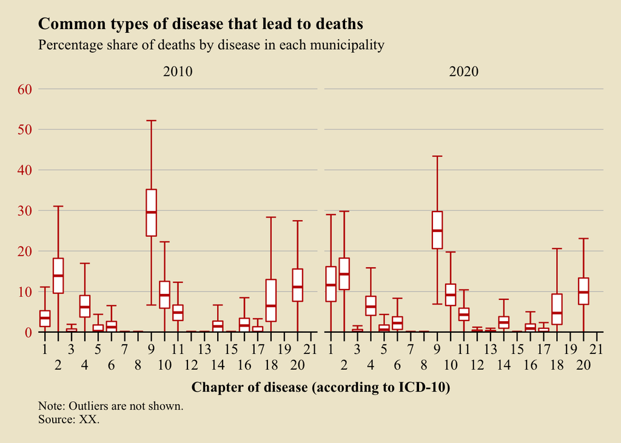

### What are common types of diseases that leads to hospitalization?

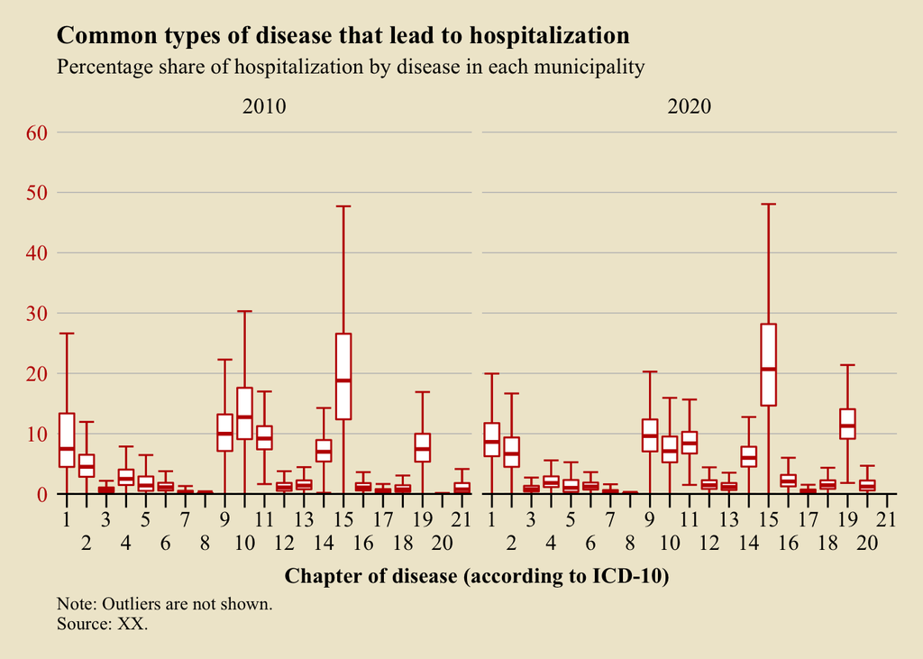

**To be confirmed / discussed**  
- Chapters 1 (Certain Infectious and Parasitic Diseases), 9, 10 (Diseases of the Respiratory System), 11 (Diseases of the Digestive System), 15 (Pregnancy, Childbirth, and the Puerperium), 19 (Injury, poisoning, and certain other consequences of external causes) seem to be the popular causes of hospitalization. I think the biggest finding of this quick observational study is that Chapter 15 is the biggest cause of hospitalization in most municipalities. Should we measure the burden of "disease" using the figures related to Chapter 15? Do you think it would be better to sum up the numbers of hospitalization due to diseases classified as Chapters 1-14 (items that include the word "disease") and divide by the population so that the indicator can be comparable across municipalities with different population size?